# Morphological Measurements On Leptograspus Crabs

Gema Martínez Sánchez

2023-11-27

```r
knitr::opts_chunk$set(echo = FALSE, eval=TRUE, message=FALSE, warning = FALSE)
```

## Introduction

The rock crab Leptograpsus variegatus (Fabricius, 1793), is recorded as occurring on a number of southern Pacific islands, the western coast of South America, and the coasts of Australia south of the Tropic of Capricorn (Balss 1935; Griffin 1969). Mahon (1973), using ecological studies which extended those of Shield (1959), and a genetical analysis based on an electrophoretic study, established the specific distinctness of rock crabs of the blue and orange forms of the genus Leptograpsus which occur on the coasts of Australia. These colour forms were previously regarded as morphs of L. variegatus (Shield 1959; Griffin 1973).  
The conclusion that the two colour forms are indeed two separate species has made it necessary to examine the extant type material of all the taxa previously placed in the synonymy of L. vauiegatus. This is necessary to determine whether any of these taxa are available for the two Western Australian species; the types of L. variegatus itself are apparently lost (Rathbun 1918). However, leptograpsid crabs which have been chemically preserved lose their distinguishing colour. In an attempt to resolve this problem of identification, a morphological study of the Western Australian species was undertaken.  
In this study, 200 animals (50 males and 50 females of each colour form) were collected at Fremantle, W.A. (32”S., 117”E.). All samples were collected and measured by one of the authors (R.J.M.). Samples were collected at night, animals being captured on sight, as the collector moved along the sample area. Measurements taken were: **(1)** the width of the frontal region (lip) of the carapace, just anterior to the front tubercles **(FL)**; **(2)** the width of the posterior region of the carapace (rear width **RW**); **(3)** the length of the carapace, along the midline **(CL)**; **(4)** the maximum width of the carapace **(CW)**; **(5)** the depth of the body measured after displacement of the abdomen (only necessary for females) **(BD)**. Measurements were made with vernier calipers, to the nearest 0.1 mm.

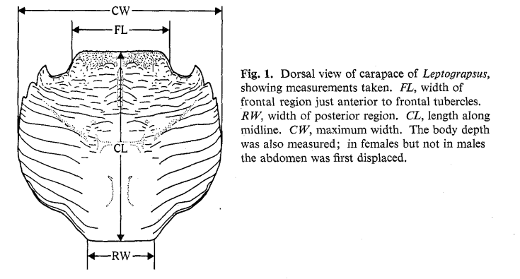

## Exploration of dataset

First of all, we need to do a quick exploration on the data we have, to know the mean, maximums, minimums, type of variables, among others.

```
## 'data.frame':    200 obs. of  9 variables:
##  $ rownames: int  1 2 3 4 5 6 7 8 9 10 ...
##  $ sp      : chr  "B" "B" "B" "B" ...
##  $ sex     : chr  "M" "M" "M" "M" ...
##  $ index   : int  1 2 3 4 5 6 7 8 9 10 ...
##  $ FL      : num  8.1 8.8 9.2 9.6 9.8 10.8 11.1 11.6 11.8 11.8 ...
##  $ RW      : num  6.7 7.7 7.8 7.9 8 9 9.9 9.1 9.6 10.5 ...
##  $ CL      : num  16.1 18.1 19 20.1 20.3 23 23.8 24.5 24.2 25.2 ...
##  $ CW      : num  19 20.8 22.4 23.1 23 26.5 27.1 28.4 27.8 29.3 ...
##  $ BD      : num  7 7.4 7.7 8.2 8.2 9.8 9.8 10.4 9.7 10.3 ...
```

```
##     rownames           sp                sex                index
##  Min.   :  1.00   Length:200         Length:200         Min.   : 1.0
##  1st Qu.: 50.75   Class :character   Class :character   1st Qu.:13.0
##  Median :100.50   Mode  :character   Mode  :character   Median :25.5
##  Mean   :100.50                                         Mean   :25.5
##  3rd Qu.:150.25                                         3rd Qu.:38.0
##  Max.   :200.00                                         Max.   :50.0
##        FL              RW              CL              CW
##  Min.   : 7.20   Min.   : 6.50   Min.   :14.70   Min.   :17.10
##  1st Qu.:12.90   1st Qu.:11.00   1st Qu.:27.27   1st Qu.:31.50
##  Median :15.55   Median :12.80   Median :32.10   Median :36.80
##  Mean   :15.58   Mean   :12.74   Mean   :32.11   Mean   :36.41
##  3rd Qu.:18.05   3rd Qu.:14.30   3rd Qu.:37.23   3rd Qu.:42.00
##  Max.   :23.10   Max.   :20.20   Max.   :47.60   Max.   :54.60
##        BD
##  Min.   : 6.10
##  1st Qu.:11.40
##  Median :13.90
##  Mean   :14.03
##  3rd Qu.:16.60
##  Max.   :21.60
```

Additionally, it will be very useful to see the proportions of the variables sex and specie in the dataset.

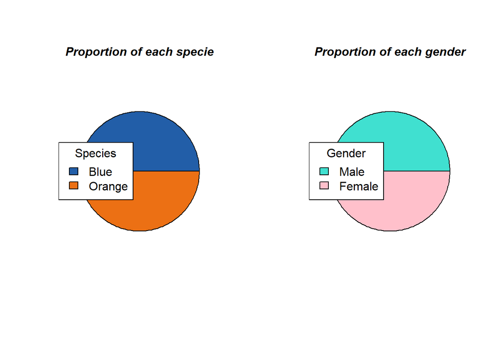

On these two pie charts we can see we have a proportion of 50/50 for blue and orange crabs and for each type of crab we have 50/50 proportion of male and female specimens. Regarding the numeric variables, we are going to analyze each of them separately.

### Frontal lobe size

As it is a numerical value, a histogram as been created showing the density of the variable data.The indexes [1] and [2] show kurtosis and skewness, respectively, in each of the variables.

```
## [1] 2.373755
```

```
## [1] 0.01090049
```

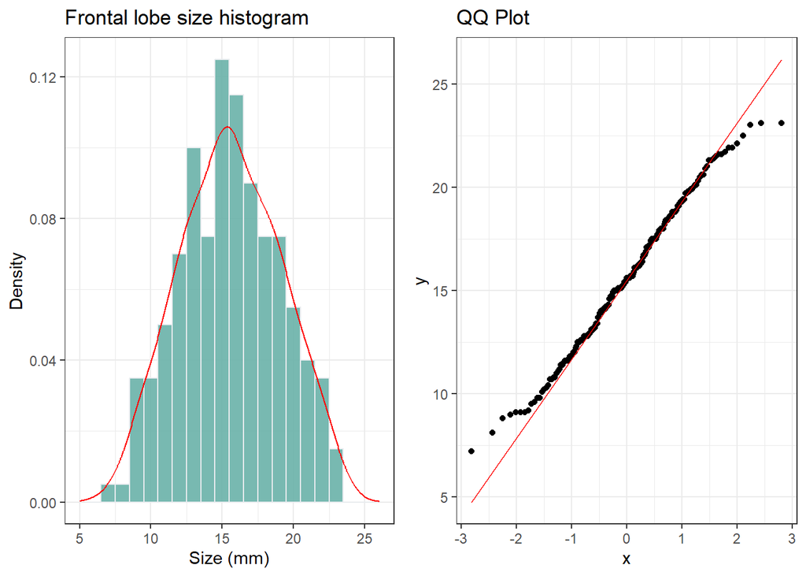

```
##
##  Shapiro-Wilk normality test
##
## data:  crabs$FL
## W = 0.99037, p-value = 0.2023
```

### Rear width

```
## [1] 2.696496
```

```
## [1] 0.02575928
```

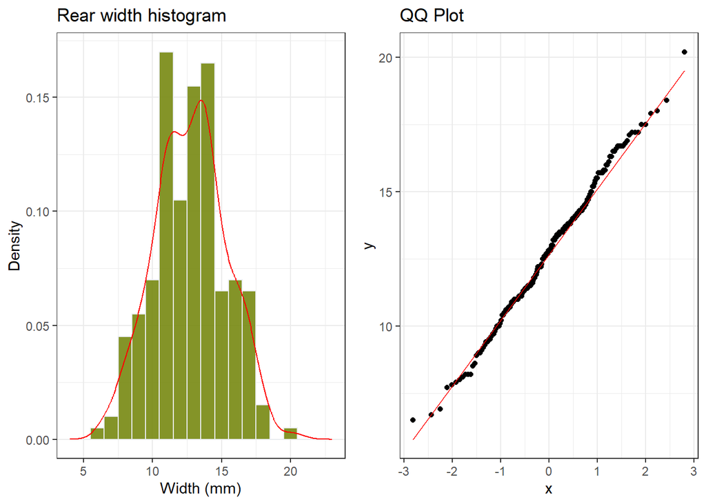

```
##
##  Shapiro-Wilk normality test
##
## data:  crabs$RW
## W = 0.9951, p-value = 0.7646
```

```
## [1] 2.425625
```

```
## [1] -0.07066927
```

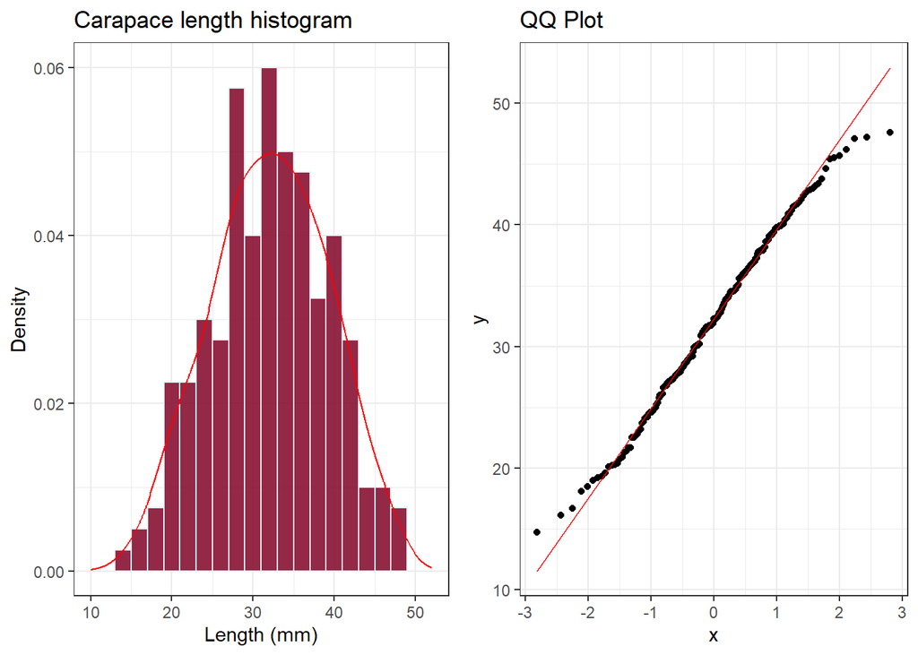

```
##
##  Shapiro-Wilk normality test
##
## data:  crabs$CL
## W = 0.9921, p-value = 0.3527
```

As the qqplot and shapiro test shows, carapace length data follows a normal distribution, as the p-value is again greater than 0.05. Data is more adjusted to the red line than for the frontal lobe size, for example, although the data of this one is still normally distributed.

### Carapace width

```
## [1] 2.424659
```

```
## [1] -0.0990868
```

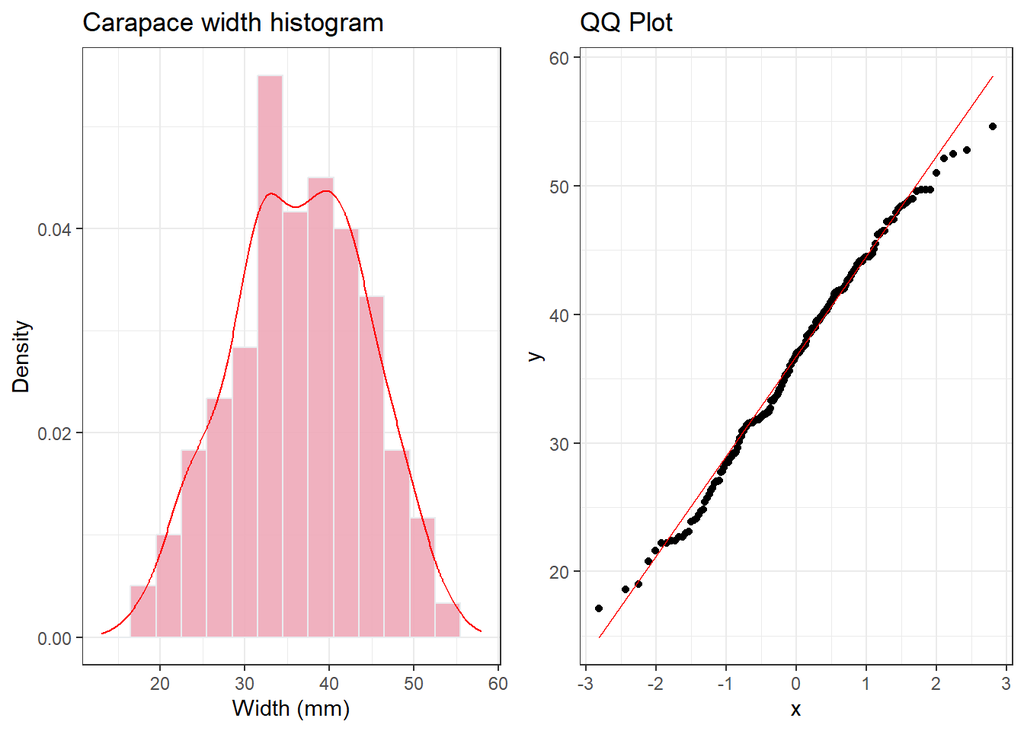

```
##
##  Shapiro-Wilk normality test
##
## data:  crabs$CW
## W = 0.99106, p-value = 0.2542
```

### Body depth

```
## [1] 2.426578
```

```
## [1] 0.0195165
```

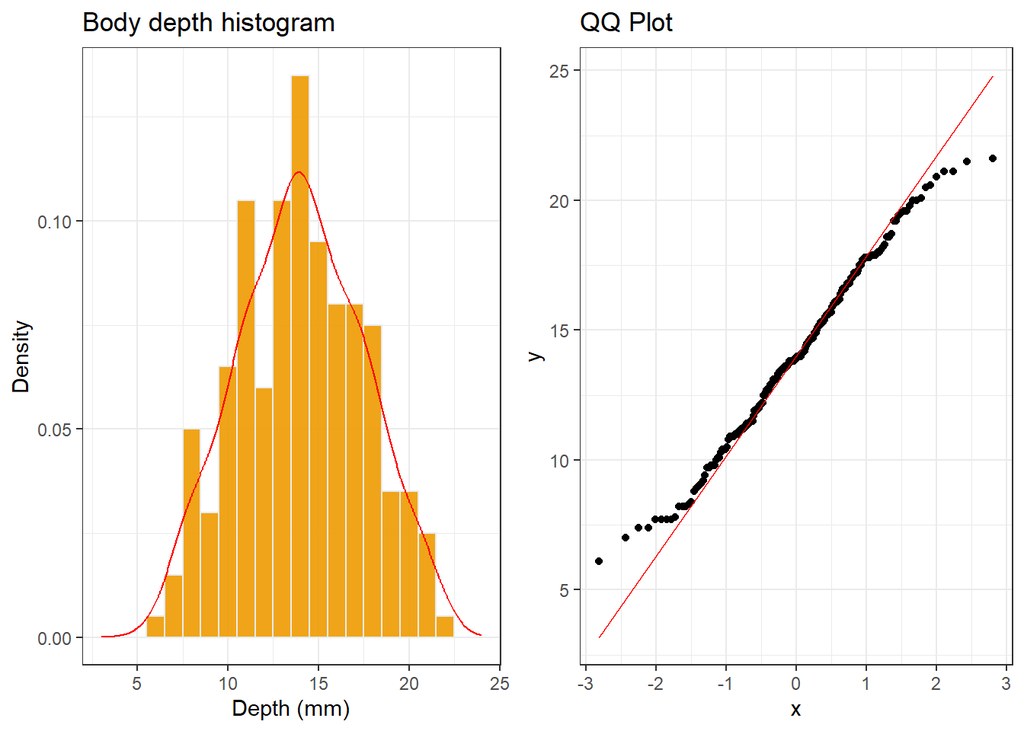

```
##
##  Shapiro-Wilk normality test
##
## data:  crabs$BD
## W = 0.99027, p-value = 0.1957
```

## Pairwise comparison of variables

Once we have check the normality of the data, it is need to do a pairwise comparison between the variables to see how they are related to each other. First we are going to create a scatterplot matrix by to see the pairwise comparison of all variables at the same time, coloured by specie.

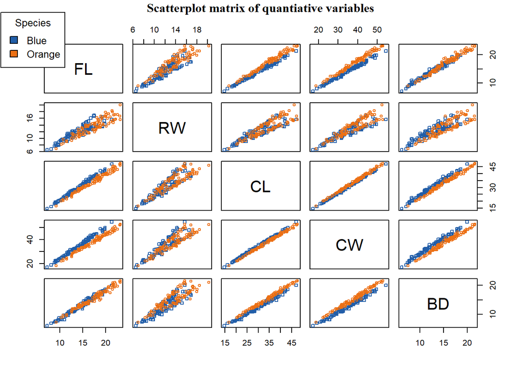

Here we an see that all variables have a positive correlation, so that means when, for example, carapace width increases, so does body depth.We don’t have separation by gender, as it has been done only by specie. If we pay attention to the different species, in some scatterplots they are overlapped, showing that there is no difference between species. But in some others, there is minimal overlapping, so this clearly needs further investigation.  
Another interesting thing is that in some scatterplots as, for example, rear width vs carapace length, we can see that the blue specie has been separated in two groups, as well as the orange specie, so this means that maybe there are some differences between gender, but we cannot see them well in this scatterplot. For this reason, it is necessary to create a scatterplot matrix by gender.

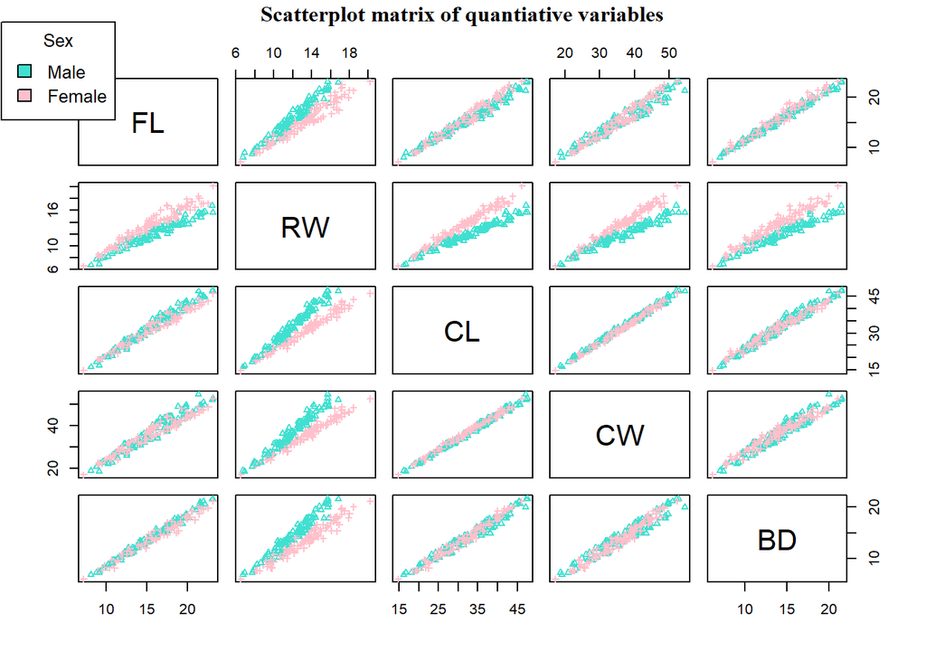

Similarly to the scatterplot matrix by specie, this scatterplot matrix by gender has a positive correlation in all scatterplots and we also see that some of the scatterplots that show overlapping by specie, do not show overlapping by gender, so this could help to differentiate crabs gender, although this is not the purpose of this investigation. For example, if we pay attention to rear width vs carapace length, in the previous scatterplot we saw two different groups within the blue species but in this scatterplot, we do not see a distinction within the same gender in any of the two genders but the two genders have minimal overlapping. This could mean that there are some differences in either rear width or carapace length by gender but not by specie. This needs further investigation through statistical analysis.

These scatterplots are very useful to understand how variables are related, but the conclusions need further investigation through statistical analysis in order to make such assumptions.

## Principal Component Analysis (PCA)

Due to the amount of variables to compare, it is useful to reduce dimensionality of the dataset using Principal Component Analysis (PCA). The principal components are ordered by decreasing amount of variance, as we can see in the following plot.

```
## Standard deviations (1, .., p=5):
## [1] 2.19760740 0.34369841 0.20180418 0.10084365 0.03871357
##
## Rotation (n x k) = (5 x 5):
##          PC1        PC2         PC3          PC4        PC5
## FL 0.4506925  0.1843417 -0.49070409 -0.713599005  0.1134915
## RW 0.4329445 -0.8946668 -0.05937425  0.074321338 -0.0555108
## CL 0.4521736  0.2452556  0.33310175 -0.005790425 -0.7901889
## CW 0.4503255  0.1340961  0.66420791 -0.045498128  0.5796404
## BD 0.4496457  0.2957320 -0.45117101  0.695089340  0.1538077
```

```
## Importance of components:
##                           PC1     PC2     PC3     PC4     PC5
## Standard deviation     2.1976 0.34370 0.20180 0.10084 0.03871
## Proportion of Variance 0.9659 0.02363 0.00814 0.00203 0.00030
## Cumulative Proportion  0.9659 0.98952 0.99767 0.99970 1.00000
```

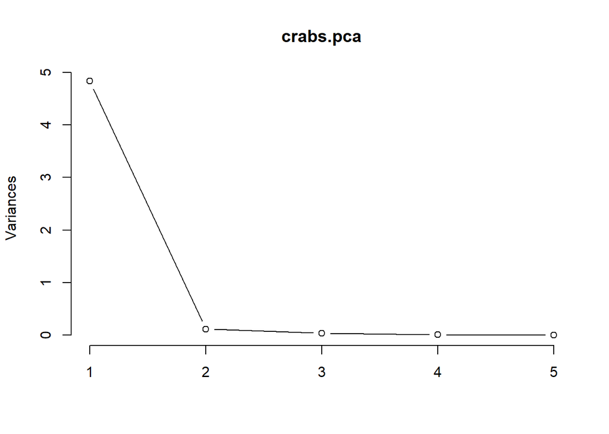

As we can see in the plot. the biggest part of the variance and standard deviation is in the first principal component (PC1) and if we pay attention to the PCA analysis, we can see that the first principal component is mainly affected by carapace length, carapace width and front lobe size but there is not so many difference with the contribution of body depth and rear width. This is partially in consonance with our theory of carapace length and width as the main variables that could serve as an indicator to separate blue and orange leptograspus crabs into different species.

### 3d PCA

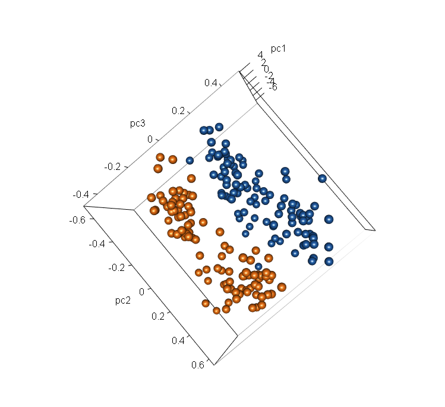

As the biggest variance is found in the first three principal components, we only need a 3d PCA plot including these ones. If we check the 3d plot, we can see that we were right, there are two groups clearly separated by specie. The blue spheres correspond to the blue specie and the orange ones to the orange specie.This is something that cannot be appreciated in a 2d plot.  
Now we are going to check the 3d PCA plot by gender.

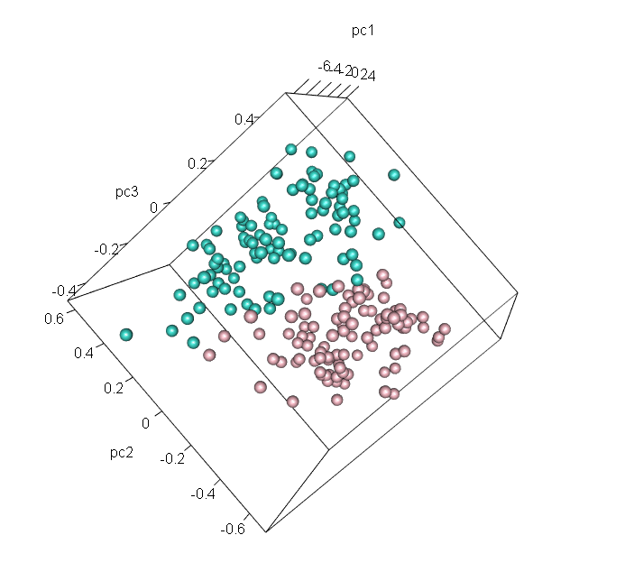

Here we can see again two groups, the blue spheres corresponding to male crabs and the pink ones to female crabs. Also it is noticeable that within each group, another two groups of spheres, that probably correspond to the two species of crabs. The separation of groups is not that clear as in the last 3d plot but it is still valid, so this proves again that could be significant differences between genders and species and especially for the species if the differences are big enough, this could prove that orange crabs and blue crabs belong to different species.

## Statistical analysis

Once we have analyzed our data graphically, it is time to perform some statistical analysis to check if the assumptions we have made are correct or not. First, a null hypothesis and an alternative hypothesis are needed. The null hypothesis (that is the one commonly accepted) is that the blue and the orange leptograspus crabs belong to the same specie and there is not any significant difference between species. The alternative hypothesis is that blue and orange crabs come from different species. As it is also useful to check if the variables sex and specie have a significant interaction between them, we perform a two-way ANOVA test.

## Two-way ANOVA

### Front lobe size

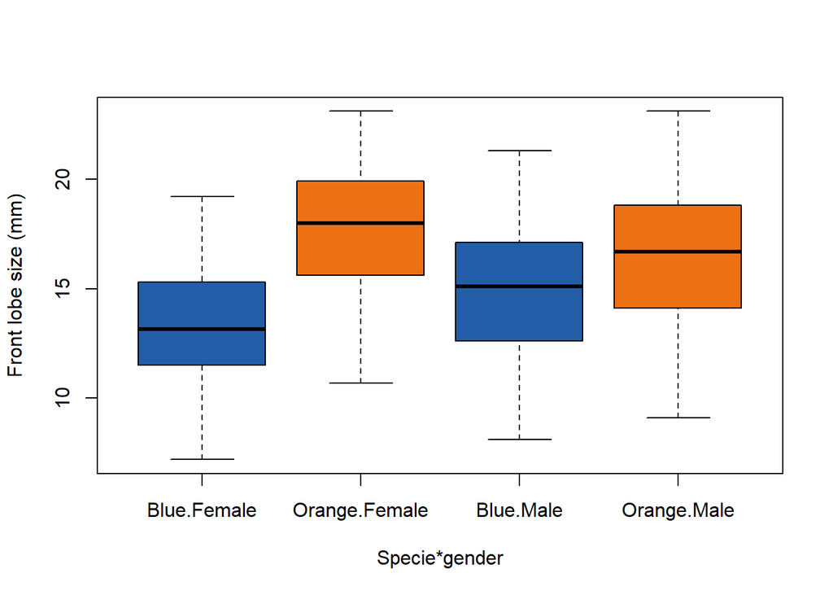

```
##
## Call:
## lm(formula = FL ~ sp * sex, data = crabs)
##
## Residuals:
##    Min     1Q Median     3Q    Max
## -7.526 -2.309  0.158  2.188  6.474
##
## Coefficients:
##                  Estimate Std. Error t value Pr(>|t|)
## (Intercept)       13.2700     0.4380  30.300  < 2e-16 ***
## spOrange           4.3240     0.6194   6.981 4.42e-11 ***
## sexMale            1.5720     0.6194   2.538  0.01192 *
## spOrange:sexMale  -2.5400     0.8759  -2.900  0.00416 **
## ---
## Signif. codes:  0 '***' 0.001 '**' 0.01 '*' 0.05 '.' 0.1 ' ' 1
##
## Residual standard error: 3.097 on 196 degrees of freedom
## Multiple R-squared:  0.2269, Adjusted R-squared:  0.215
## F-statistic: 19.17 on 3 and 196 DF,  p-value: 6.084e-11
```

|  | Df | Sum Sq | Mean Sq | F value | Pr(>F) |
| --- | --- | --- | --- | --- | --- |
| sp | 1 | 466.3458 | 466.345800 | 48.6270175 | 4.626989e-11 |
| sex | 1 | 4.5602 | 4.560200 | 0.4755032 | 4.912819e-01 |
| sp:sex | 1 | 80.6450 | 80.645000 | 8.4090514 | 4.159687e-03 |
| Residuals | 196 | 1879.6912 | 9.590261 | NA | NA |

```
##                       2.5 %     97.5 %
## (Intercept)      12.4062894 14.1337106
## spOrange          3.1025288  5.5454712
## sexMale           0.3505288  2.7934712
## spOrange:sexMale -4.2674211 -0.8125789
```

As we can see in the boxplot, there are some differences in the mean value between groups, but in order to be sure about this,we perform an ANOVA test. If we check the p-values, there are significant differences between species but not between males and females. Also, it exists an interaction between specie and gender.

### Rear width

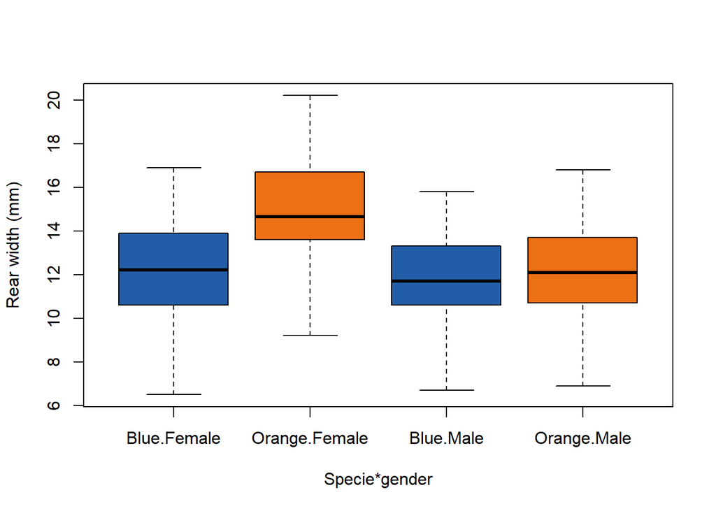

```
##
## Call:
## lm(formula = RW ~ sp * sex, data = crabs)
##
## Residuals:
##    Min     1Q Median     3Q    Max
## -5.638 -1.280  0.000  1.688  5.364
##
## Coefficients:
##                  Estimate Std. Error t value Pr(>|t|)
## (Intercept)       12.1380     0.3220  37.691  < 2e-16 ***
## spOrange           2.6980     0.4554   5.924 1.39e-08 ***
## sexMale           -0.4200     0.4554  -0.922 0.357561
## spOrange:sexMale  -2.1540     0.6441  -3.344 0.000988 ***
## ---
## Signif. codes:  0 '***' 0.001 '**' 0.01 '*' 0.05 '.' 0.1 ' ' 1
##
## Residual standard error: 2.277 on 196 degrees of freedom
## Multiple R-squared:  0.2287, Adjusted R-squared:  0.2169
## F-statistic: 19.38 on 3 and 196 DF,  p-value: 4.813e-11
```

|  | Df | Sum Sq | Mean Sq | F value | Pr(>F) |
| --- | --- | --- | --- | --- | --- |
| sp | 1 | 131.38205 | 131.382050 | 25.33626 | 1.087125e-06 |
| sex | 1 | 112.05045 | 112.050450 | 21.60828 | 6.132855e-06 |
| sp:sex | 1 | 57.99645 | 57.996450 | 11.18428 | 9.883659e-04 |
| Residuals | 196 | 1016.36460 | 5.185534 | NA | NA |

The boxplot shows a difference between means by specie but not so obvious as for the frontal lobe size. Checking the ANOVA results we can see that the differences are significant for both specie and gender groups, and the interaction between groups is also significant.

### Carapace length

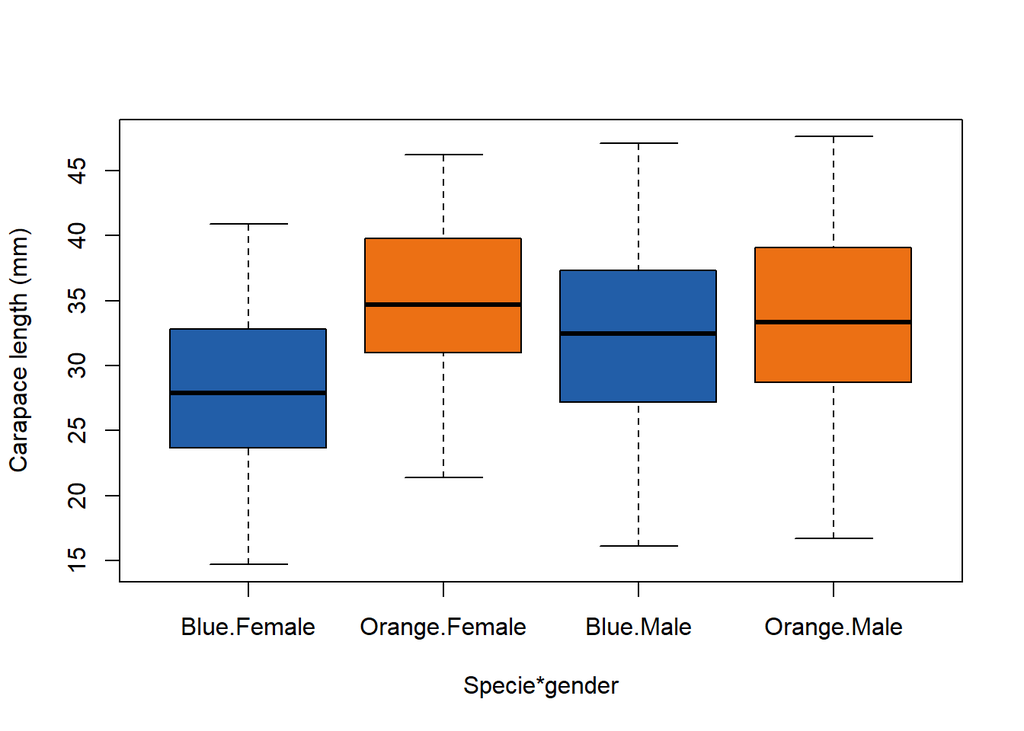

```
##
## Call:
## lm(formula = CL ~ sp * sex, data = crabs)
##
## Residuals:
##     Min      1Q  Median      3Q     Max
## -16.988  -4.636   0.184   5.130  15.086
##
## Coefficients:
##                  Estimate Std. Error t value Pr(>|t|)
## (Intercept)       28.1020     0.9499  29.584  < 2e-16 ***
## spOrange           6.5160     1.3434   4.851  2.5e-06 ***
## sexMale            3.9120     1.3434   2.912  0.00401 **
## spOrange:sexMale  -4.8420     1.8998  -2.549  0.01158 *
## ---
## Signif. codes:  0 '***' 0.001 '**' 0.01 '*' 0.05 '.' 0.1 ' ' 1
##
## Residual standard error: 6.717 on 196 degrees of freedom
## Multiple R-squared:  0.1232, Adjusted R-squared:  0.1098
## F-statistic: 9.181 on 3 and 196 DF,  p-value: 1.031e-05
```

|  | Df | Sum Sq | Mean Sq | F value | Pr(>F) |
| --- | --- | --- | --- | --- | --- |
| sp | 1 | 838.4513 | 838.45125 | 18.584553 | 2.571914e-05 |
| sex | 1 | 111.1541 | 111.15405 | 2.463767 | 1.181121e-01 |
| sp:sex | 1 | 293.0620 | 293.06205 | 6.495818 | 1.157873e-02 |
| Residuals | 196 | 8842.6366 | 45.11549 | NA | NA |

As well as with the previous variables analyzed, carapace length shows differences by specie but not by gender, as expected regarding the previous analyses.This is shown in the boxplot and confirmed through the ANOVA test.The interaction between gender and specie is also significant.

### Carapace width

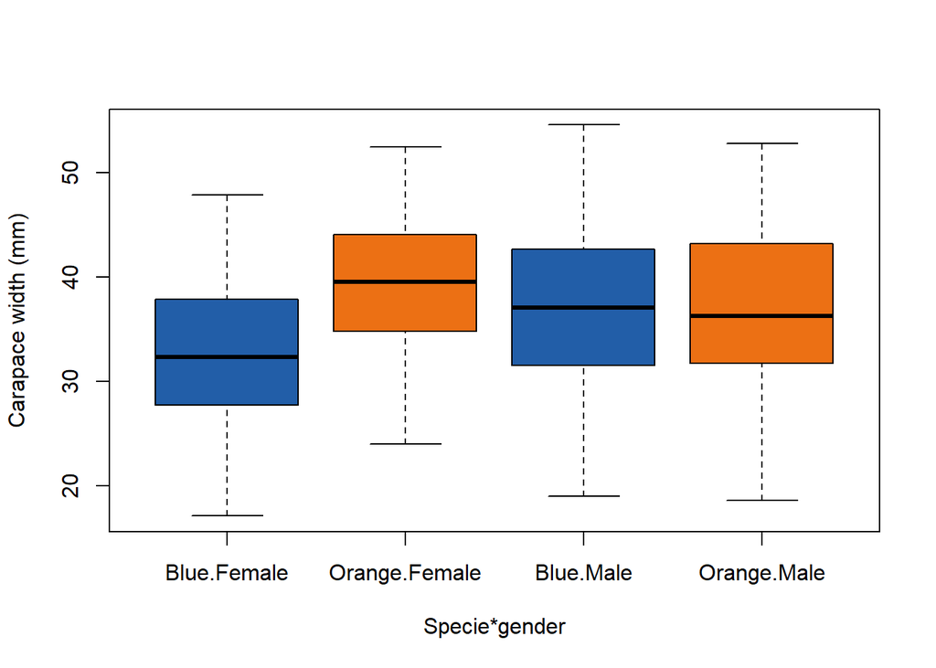

```
##
## Call:
## lm(formula = CW ~ sp * sex, data = crabs)
##
## Residuals:
##     Min      1Q  Median      3Q     Max
## -18.588  -5.293   0.151   5.335  17.790
##
## Coefficients:
##                  Estimate Std. Error t value Pr(>|t|)
## (Intercept)        32.624      1.071  30.474  < 2e-16 ***
## spOrange            6.412      1.514   4.235 3.51e-05 ***
## sexMale             4.186      1.514   2.765  0.00624 **
## spOrange:sexMale   -6.034      2.141  -2.818  0.00533 **
## ---
## Signif. codes:  0 '***' 0.001 '**' 0.01 '*' 0.05 '.' 0.1 ' ' 1
##
## Residual standard error: 7.57 on 196 degrees of freedom
## Multiple R-squared:  0.08918,    Adjusted R-squared:  0.07524
## F-statistic: 6.397 on 3 and 196 DF,  p-value: 0.0003716
```

|  | Df | Sum Sq | Mean Sq | F value | Pr(>F) |
| --- | --- | --- | --- | --- | --- |
| sp | 1 | 576.30125 | 576.30125 | 10.056696 | 0.001761988 |
| sex | 1 | 68.32805 | 68.32805 | 1.192353 | 0.276195878 |
| sp:sex | 1 | 455.11445 | 455.11445 | 7.941936 | 0.005325409 |
| Residuals | 196 | 11231.82420 | 57.30523 | NA | NA |

As expected, carapace width shows significant differences between blue and orange crabs but not between males and females. This is shown in the boxplot and confirmed through ANOVA testing. The interaction gender-specie is also significant.

### Body depth

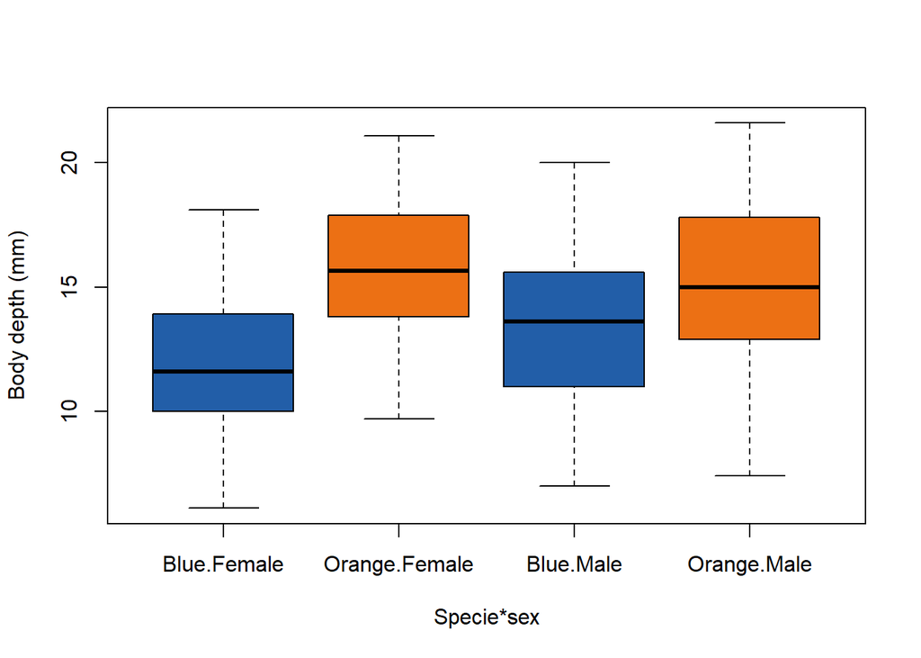

```
##
## Call:
## lm(formula = BD ~ sp * sex, data = crabs)
##
## Residuals:
##    Min     1Q Median     3Q    Max
## -7.924 -2.224  0.059  2.250  6.650
##
## Coefficients:
##                  Estimate Std. Error t value Pr(>|t|)
## (Intercept)       11.8160     0.4349  27.167  < 2e-16 ***
## spOrange           3.8160     0.6151   6.204 3.21e-09 ***
## sexMale            1.5340     0.6151   2.494   0.0135 *
## spOrange:sexMale  -1.8420     0.8699  -2.118   0.0355 *
## ---
## Signif. codes:  0 '***' 0.001 '**' 0.01 '*' 0.05 '.' 0.1 ' ' 1
##
## Residual standard error: 3.075 on 196 degrees of freedom
## Multiple R-squared:  0.2058, Adjusted R-squared:  0.1936
## F-statistic: 16.93 on 3 and 196 DF,  p-value: 8.131e-10
```

|  | Df | Sum Sq | Mean Sq | F value | Pr(>F) |
| --- | --- | --- | --- | --- | --- |
| sp | 1 | 419.05125 | 419.051250 | 44.305005 | 2.751275e-10 |
| sex | 1 | 18.78845 | 18.788450 | 1.986445 | 1.602977e-01 |
| sp:sex | 1 | 42.41205 | 42.412050 | 4.484096 | 3.547225e-02 |
| Residuals | 196 | 1853.83220 | 9.458328 | NA | NA |

As shown in the boxplot and later confirmed through ANOVA test, differences in means are significant for the body depth regarding the specie of leptograspus crab, but not he gender.The interaction between gender and specie is also significant.

In conclusion, all the variables in this dataset show significant differences between blue and orange species, so this supports the alternative hypothesis that blue crabs and orange forms are different species of Leptograspus crab. Additionally, rear width shows significant differences by gender, supporting the theory that rear width could serve as an indicator to differentiate male and female crabs, as sown in the scatterplots previously. Also gender and specie show a significant correlation in all the variables studied, so this clearly needs further analysis.

## Matrix of correlations

### By specie

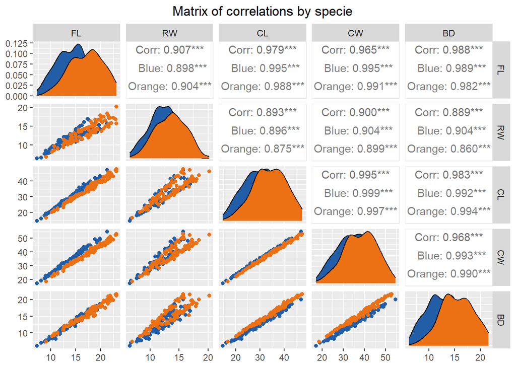

This matrix of correlations show that all the variables are positive correlated between them, as we can tell if we look at the scatterplots. All the correlation coefficients are close to 1, meaning that it exists a strong positive correlation between the different measurements.

### By gender

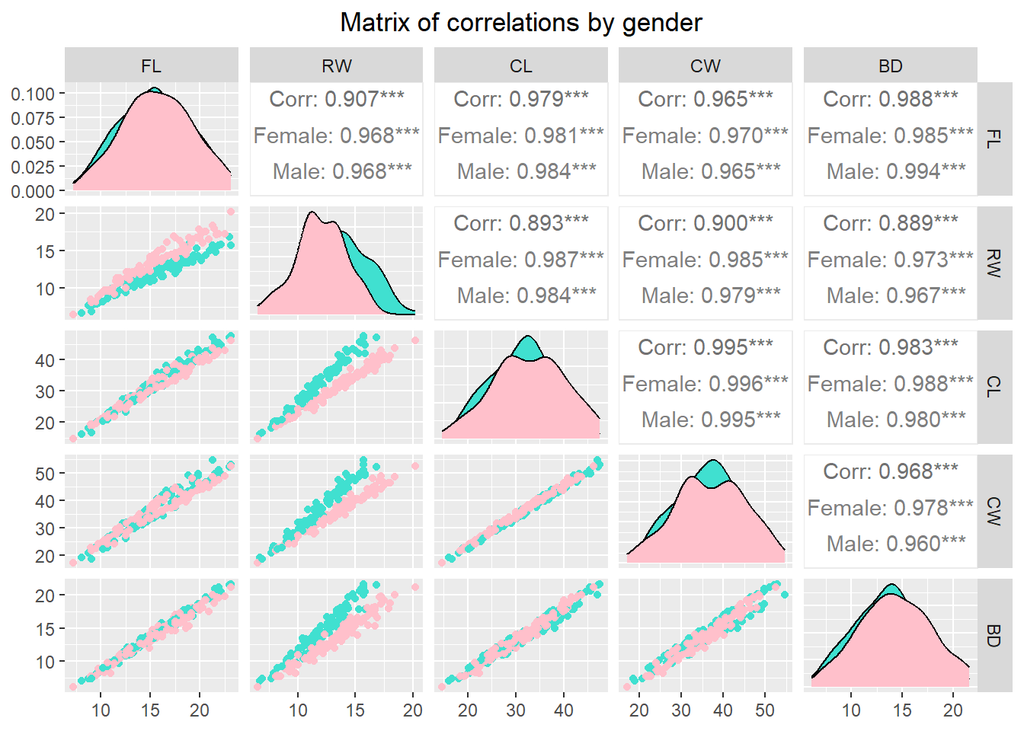

## Conclusions

All of these results and previous investigations show good evidence that blue and orange leptograspus crabs are in fact two different species and we could use the color and carapace dimensions to identify them.